```python
from manim import *
import numpy as np
config.media_embed = True
config.verbosity = "WARNING"
```

# Electric Potential Energy

Let's first recall the basic expressions for work and energy. We note that work is the energy inputted into an object when a force is applied to the object over a distance. The work-kinetic energy theorem is

\begin{equation} \Delta \text{K.E.} = \int_A^B \vec{F} \cdot d \vec{s} \end{equation}

If the force is conservative, the work is independent of path. Therefore, the work can be computed by evaluating a potential energy function at the endpoints of the path \begin{equation} \Delta U = - W. \end{equation}

The potential energy is related to the force (one-dimensional version) via the gradient relationship \begin{equation} F = - \frac{dU}{ds}. \end{equation}

## Problem 1

The plot below shows the potential energy of particle, $U(x)$. Use the plot to answer the following.

**At which position ($x = 3$, $x = 6$, or $x = 8$) does the particle experience the strongest force pointing in the negative x-direction?**

**Click to see the answer and explanation**

The correct position is **$x = 6$**.

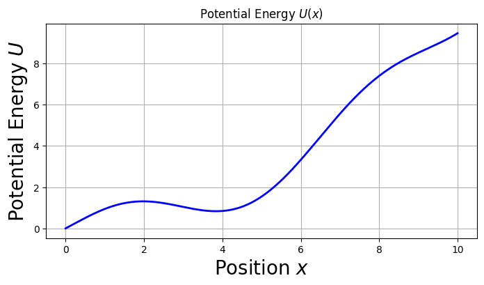

```python
import numpy as np
import matplotlib.pyplot as plt

x = np.linspace(0, 10, 500)
# A simple potential energy function: U(x) = sin(x) + 0.1*x^2
u_x = np.sin(x) + 0.1 * x**2

plt.figure(figsize=(8, 4))
plt.plot(x, u_x, 'b-', linewidth=2)
plt.title("Potential Energy $U(x)$")
plt.xlabel("Position $x$", size=20)
plt.ylabel("Potential Energy $U$", size=20)
plt.grid(True)
plt.show()
```

```python
from energy_scences import EPotentialEnergy

from manim import *
config.media_embed = True
config.verbosity = "WARNING"
%manim -qm EPotentialEnergy
```

```
Manim Community v0.19.0
```

[video not shown]

# Electric Potential Energy for Point Charges

The electric potential energy for point charges is \begin{equation} U = k \frac{q_1 q_2}{r} \end{equation}

### Problem 2

Is the potential energy a vector or a scalar?

**Click to see the answer**

The correct answer is: scalar.

Energy, including electric potential energy, does not have a direction associated with it. While the electric field and electric force are vectors, potential energy is a single numerical value (measured in Joules) that depends only on the relative positions and magnitudes of the charges.

### Problem 3

For two point charges, the potential energy is $U= k\frac{q_1 q_2}{r}$, what is $r$?

**Click to see the answer**

The variable $r$ represents the distance between the two point charges.

It is a scalar quantity representing the magnitude of the separation vector. In Cartesian coordinates, if charge 1 is at $(x_1, y_1)$ and charge 2 is at $(x_2, y_2)$, then $r = \sqrt{(x_2-x_1)^2 + (y_2-y_1)^2}$.

### Problem 4

If two charges have the same sign (both positive or both negative), is the potential energy of the system positive or negative? What does this imply about the work required to bring them together?

**Click to see the answer**

The potential energy is **positive**.

Since like charges repel, you must do work against the electric force to bring them closer together. This external work is stored as positive potential energy in the system. If you released the charges, they would accelerate away from each other, converting that stored potential energy into kinetic energy.

### Problem 5

If the force is constant, how does the potential energy depend on position? Show results for constant e-field and gravitational field.

**Click to see the answer**

If the force $\vec{F}$ is constant, the potential energy depends **linearly** on the position coordinates.

Using the relationship $\vec{F} = -\nabla U$, or in one dimension $F = -dU/ds$, we integrate to find $U = -Fs + C$.

- **Constant Gravitational Field:** Near the surface of the Earth, the force is $\vec{F} = -mg\hat{j}$. The potential energy is $U = mgy$.
- **Constant Electric Field:** For a charge $q$ in a uniform field $\vec{E} = E\hat{i}$, the force is $\vec{F} = qE\hat{i}$. The potential energy is $U = -qEx$.

### Problem 6

Two charges, each of charge $+q$, lie on the vertical y-axis at $\vec{r}_1 = a \hat{j}$ and $\vec{r}_2 = - a \hat{j}$. A third charge, $q_0$, lies on the x-axis at $\vec{r} = b \hat{i}$. What is the electric potential energy for $q_0$? Compute the electric force using Coulomb's law and also from the potential energy.

**Click to see the answer**

**1. Potential Energy ($U$):** The distance from $q_0$ to either charge $+q$ is $r = \sqrt{a^2 + b^2}$. The total potential energy is the sum of the interactions: \begin{equation} U = k\frac{q q_0}{\sqrt{a^2 + b^2}} + k\frac{q q_0}{\sqrt{a^2 + b^2}} = \frac{2k q q_0}{\sqrt{a^2 + b^2}} \end{equation}

**2. Force via Coulomb's Law:** The y-components of the forces from the two charges cancel due to symmetry. The x-components add together. The force from one charge is $F_1 = kqq_0/(a^2+b^2)$, and its x-component is $F_{1x} = F_1 \cos\theta$, where $\cos\theta = b/\sqrt{a^2+b^2}$. Thus: \begin{equation} \vec{F} = 2 \left( \frac{k q q_0}{a^2 + b^2} \right) \left( \frac{b}{\sqrt{a^2 + b^2}} \right) \hat{i} = \frac{2k q q_0 b}{(a^2 + b^2)^{3/2}} \hat{i} \end{equation}

**3. Force via Potential Energy:** We find the force by taking the negative gradient of $U$ with respect to the position of $q_0$ (the variable $b$): \begin{equation} F_x = -\frac{dU}{db} = -\frac{d}{db} \left[ 2k q q_0 (a^2 + b^2)^{-1/2} \right] \end{equation} \begin{equation} F_x = -2k q q_0 \left( -\frac{1}{2} \right) (a^2 + b^2)^{-3/2} (2b) = \frac{2k q q_0 b}{(a^2 + b^2)^{3/2}} \end{equation} Both methods yield the same result.

# Electric Potential

The electric potential is a scalar field that describes the potential energy per unit charge at any point in space.

The change in electric potential, $\Delta V$, is defined as the change in electric potential energy, $\Delta U$, per unit charge $q$ \begin{equation} \Delta V = \frac{\Delta U}{q} \end{equation}

**Units:** The SI unit for electric potential is the **Volt (V)**. One volt is equivalent to one **Joule per Coulomb (J/C)**.

## Relationship to the Electric Field

We can derive the relationship between potential and the electric field by starting with the definition of work and potential energy. The change in potential energy is equal to the negative of the work done by a conservative force \begin{equation} \Delta U = -W = -\int_A^B \mathbf{F} \cdot d\mathbf{s} \end{equation} Since the electric force on a test charge is $\mathbf{F} = q\mathbf{E}$, we substitute this into the integral \begin{equation} \Delta U = -\int_A^B q\mathbf{E} \cdot d\mathbf{s} \end{equation} Dividing both sides by the charge $q$ gives the relationship for the potential difference \begin{equation} \Delta V = -\int_A^B \mathbf{E} \cdot d\mathbf{s} \end{equation} In one dimension, this integral relationship implies that the electric field is the negative gradient of the potential \begin{equation} E = -\frac{dV}{ds}. \end{equation}

In many problems we approximate the magnitude of the electric field as \begin{equation} E \approx -\frac{\Delta V}{\Delta s}. \end{equation}

The following Python code generates a side-by-side comparison of the potential and field for a positive and a negative point source. The dashed lines represent equipotential surfaces (lines where $V$ is constant), and the vectors show the direction of the electric field $\mathbf{E}$.

Note the following:

- the electric field is perpendicular to the equipotential lines
- the electric field points toward lower potential

  ```
  - hence positive charges move toward lower potential
  - negative charges move toward high potential
  ```

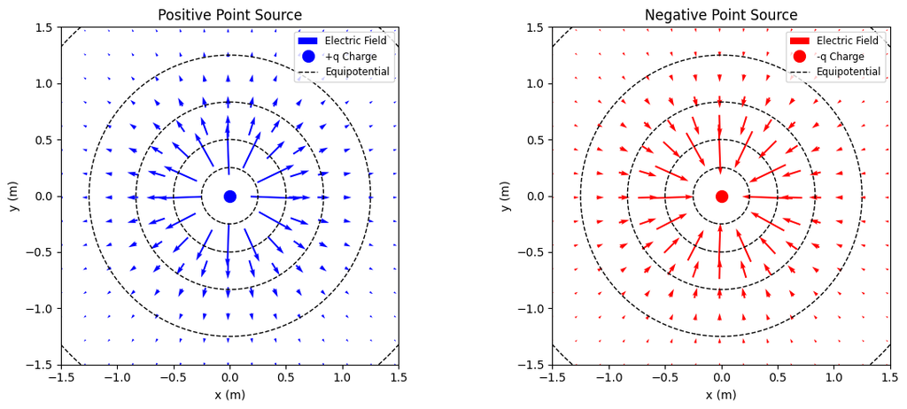

```python
import numpy as np
import matplotlib.pyplot as plt
from matplotlib.lines import Line2D

# Setup coordinates
x = np.linspace(-1.5, 1.5, 100)
y = np.linspace(-1.5, 1.5, 100)
X, Y = np.meshgrid(x, y)
R = np.sqrt(X**2 + Y**2)

# Strict exclusion radius threshold: No field lines for r < 0.25
strict_exclusion_radius = 0.4
mask = R < strict_exclusion_radius

# Define potentials
R_v_safe = np.where(R < 0.05, 0.05, R)
V_pos = 1 / R_v_safe
V_neg = -1 / R_v_safe

# Electric field components: Masked within the strict threshold radius
Ex_pos = np.where(mask, np.nan, X / R**3)
Ey_pos = np.where(mask, np.nan, Y / R**3)
Ex_neg = np.where(mask, np.nan, -X / R**3)
Ey_neg = np.where(mask, np.nan, -Y / R**3)

fig, (ax1, ax2) = plt.subplots(1, 2, figsize=(12, 5))

# Manual levels for equipotentials
levels_pos = [0.5, 0.8, 1.2, 2.0, 4.0]
levels_neg = [-4.0, -2.0, -1.2, -0.8, -0.5]

# Create a proxy artist for the legend to represent equipotential lines
equipot_line = Line2D([0], [0], color='black', linestyle='--', linewidth=1, label='Equipotential')

# Subsampling for field arrows
skip = 7

# Plot Positive Charge (Blue)
ax1.contour(X, Y, V_pos, levels=levels_pos, colors='black', linestyles='dashed', linewidths=1)
ax1.quiver(X[::skip, ::skip], Y[::skip, ::skip],
           Ex_pos[::skip, ::skip], Ey_pos[::skip, ::skip],
           color='blue', pivot='mid', scale=40, width=0.005, label='Electric Field')
ax1.plot(0, 0, 'bo', markersize=10, label='+q Charge')
ax1.set_title("Positive Point Source")

# Plot Negative Charge (Red)
ax2.contour(X, Y, V_neg, levels=levels_neg, colors='black', linestyles='dashed', linewidths=1)
ax2.quiver(X[::skip, ::skip], Y[::skip, ::skip],
           Ex_neg[::skip, ::skip], Ey_neg[::skip, ::skip],
           color='red', pivot='mid', scale=40, width=0.005, label='Electric Field')
ax2.plot(0, 0, 'ro', markersize=10, label='-q Charge')
ax2.set_title("Negative Point Source")

for ax in [ax1, ax2]:
    ax.set_aspect('equal')
    ax.set_xlabel("x (m)")
    ax.set_ylabel("y (m)")
    ax.set_xlim(-1.5, 1.5)
    ax.set_ylim(-1.5, 1.5)

    # Consolidate legend handles: charge plot, field quiver, and proxy line
    handles, labels = ax.get_legend_handles_labels()
    handles.append(equipot_line)
    ax.legend(handles=handles, loc='upper right', fontsize='small')

plt.tight_layout()
plt.show()
```

### Problem 7

Two parallel conducting plates are separated by a distance $d = 12.0 \text{ cm}$. One of the plates is maintained at $V = 0 \text{ V}$.

**(a)** Determine the electric field strength between the plates if the potential at a distance of $9.00 \text{ cm}$ from the zero-volt plate is $540 \text{ V}$.  
**(b)** Calculate the total voltage (potential difference) between the two plates.

**Hint 1: Relationship between Field and Potential**

For parallel conducting plates, the electric field $E$ is uniform. This is assuming the distance between the plates is small compared to the length of the plates and we are not looking at the edges of the plates --> this is an infitie plate approximation.

The relationship between the potential difference $\Delta V$, the constant electric field $E$, and the distance $\Delta x$ is given by:

$$E = \frac{\Delta V}{\Delta x}$$

Use the given point ($x = 9.00 \text{ cm}$, $V = 540 \text{ V}$) relative to the zero-volt reference to find the field strength.

**Hint 2: Finding Total Potential Difference**

Once the uniform electric field $E$ is determined, the potential at any point between the plates is proportional to its distance from the reference plate. The total voltage between the plates is the potential difference across the entire separation distance $d = 12.0 \text{ cm}$.

$$V_{\text{total}} = E \times d$$

**Solution**

**Part (a):** The potential difference relative to the zero-volt plate is $\Delta V = 540 \text{ V} - 0 \text{ V} = 540 \text{ V}$.  
The distance from the zero-volt plate is $x = 9.00 \text{ cm} = 0.09 \text{ m}$.

$$E = \frac{540 \text{ V}}{0.09 \text{ m}} = 6000 \text{ V/m}$$

The electric field strength is **$6.00 \times 10^3 \text{ V/m}$**.

**Part (b):** Using the uniform field strength $E$ across the full separation $d = 12.0 \text{ cm} = 0.12 \text{ m}$:

$$V_{\text{total}} = (6000 \text{ V/m}) \times (0.12 \text{ m}) = 720 \text{ V}$$

The total voltage between the plates is **$720 \text{ V}$**.

### Problem 8

Throughout a specific region of space, the equipotential surfaces are defined by the planes $z = \text{constant}$. These surfaces are equally spaced and carry the following potentials:

- $V = 150 \text{ V}$ at $z = 0.00 \text{ m}$
- $V = 300 \text{ V}$ at $z = 0.20 \text{ m}$
- $V = 450 \text{ V}$ at $z = 0.40 \text{ m}$

**What is the electric field vector $\mathbf{E}$ in this region?**

**Hint 1: Understanding Equipotential Geometry**

Equipotential surfaces are always perpendicular to the electric field lines. Since the surfaces are planes defined by $z = \text{constant}$ (horizontal layers), the electric field must point strictly along the $z$-axis.

Recall that the electric field points from **higher potential to lower potential**.

**Hint 2: Calculating Magnitude and Direction**

For a uniform field, the magnitude is the change in potential divided by the distance moved perpendicular to the surfaces:

$$E = -\frac{\Delta V}{\Delta z}$$

Calculate the change in voltage between two known planes (e.g., from $z=0$ to $z=0.20$) and divide by the displacement. The negative sign in the formula $\mathbf{E} = -\nabla V$ indicates the direction.

**Solution**

**Step 1: Calculate the Magnitude** The potential increases by $150 \text{ V}$ for every $0.20 \text{ m}$ increase in $z$.

$$E_z = -\frac{V_2 - V_1}{z_2 - z_1} = -\frac{300 \text{ V} - 150 \text{ V}}{0.20 \text{ m} - 0.00 \text{ m}}$$ $$E_z = -\frac{150 \text{ V}}{0.20 \text{ m}} = -750 \text{ V/m}$$

**Step 2: Determine the Direction** Because the potential increases as $z$ increases, the electric field (which points toward decreasing potential) must point in the negative $z$-direction.

**Final Answer:** The electric field is uniform and is given by: $$\mathbf{E} = -750\hat{k} \text{ V/m}$$ (or $750 \text{ V/m}$ in the $-z$ direction).

### Problem 9

Find the ratio of speeds of an electron and a negative hydrogen ion (an ion with one extra electron) accelerated through the same voltage, assuming non-relativistic final speeds. Take the mass of the hydrogen ion to be $1.67 \times 10^{-27} \text{ kg}$ and the mass of the electron to be $9.11 \times 10^{-31} \text{ kg}$.

**Hint: Energy Conservation**

When a charged particle is accelerated through a potential difference $V$, its electrical potential energy is converted into kinetic energy. The work done on the particle is: $$W = qV$$

Setting this equal to the kinetic energy: $$qV = \frac{1}{2}mv^2$$

Since both particles have the same magnitude of charge (one extra electron for the ion), they gain the exact same amount of energy.

Solve the energy equation for velocity $v$: $$v = \sqrt{\frac{2qV}{m}}$$

To find the ratio $v_e / v_H$, divide the velocity expression for the electron by the expression for the ion. Note that $q$ and $V$ are identical for both, so they will cancel out, leaving you with a relationship based purely on the inverse of the masses.

**Solution**

**Step 1: Express the velocities** For the electron: $v_e = \sqrt{\frac{2eV}{m_e}}$  
For the H⁻ ion: $v_H = \sqrt{\frac{2eV}{m_H}}$

**Step 2: Calculate the ratio** $$\frac{v_e}{v_H} = \frac{\sqrt{\frac{2eV}{m_e}}}{\sqrt{\frac{2eV}{m_H}}} = \sqrt{\frac{m_H}{m_e}}$$

**Step 3: Plug in the masses** $$\frac{v_e}{v_H} = \sqrt{\frac{1.67 \times 10^{-27} \text{ kg}}{9.11 \times 10^{-31} \text{ kg}}} \approx \sqrt{1833.15}$$ $$\frac{v_e}{v_H} \approx 42.8$$

**Final Answer:** The electron travels approximately **42.8 times faster** than the negative hydrogen ion.

### Problem 10

An evacuated tube uses an accelerating voltage of $40 \text{ kV}$ to accelerate electrons to hit a copper plate and produce X-rays. Non-relativistically, what would be the maximum speed of these electrons?

**Hint: Converting Units**

The accelerating voltage is given as $40 \text{ kV}$. Before calculating, convert this to standard Volts: $$V = 40,000 \text{ V}$$

The charge of an electron $e$ is $1.60 \times 10^{-19} \text{ C}$ and the mass $m_e$ is $9.11 \times 10^{-31} \text{ kg}$.

**Hint 2: Kinetic Energy Equation**

Use the Conservation of Energy principle where $PE_{elec} = KE$: $$\frac{1}{2}m_ev^2 = eV$$

Rearrange the formula to solve for $v$: $$v = \sqrt{\frac{2eV}{m_e}}$$

**Solution**

**Step 1: Identify known values**

- $V = 4.0 \times 10^4 \text{ V}$
- $e = 1.60 \times 10^{-19} \text{ C}$
- $m_e = 9.11 \times 10^{-31} \text{ kg}$

**Step 2: Calculate the speed** $$v = \sqrt{\frac{2(1.60 \times 10^{-19} \text{ C})(4.0 \times 10^4 \text{ V})}{9.11 \times 10^{-31} \text{ kg}}}$$ $$v = \sqrt{\frac{1.28 \times 10^{-14}}{9.11 \times 10^{-31}}}$$ $$v \approx \sqrt{1.405 \times 10^{16}}$$ $$v \approx 1.18 \times 10^8 \text{ m/s}$$

**Final Answer:** The maximum non-relativistic speed is **$1.18 \times 10^8 \text{ m/s}$**. *(Note: Since this is about 39% of the speed of light, a relativistic calculation would be needed for higher precision, but the non-relativistic value is $1.18 \times 10^8 \text{ m/s}$.)*

# Problem 11: Potential and Field of a Ring of Charge

A thin ring of radius $R$ carries a total charge $Q$ distributed uniformly along its circumference. The ring lies in the $xy$-plane, centered at the origin.

**Find the electric potential $V$ at a point $P$ located a distance $z$ from the center along the symmetry axis (the $z$-axis), and then use this potential to derive the electric field $\mathbf{E}$ at that same point.**

**Hint 1: Setting up the Potential Integral**

For a continuous charge distribution, the potential is given by: $$V = \frac{1}{4\pi\epsilon_0} \int \frac{dq}{r}$$

Consider a small element of charge $dq$ on the ring. What is the distance $r$ from $dq$ to the point $P(0,0,z)$? Since every point on the ring is the same distance from the axis, $r$ will be constant for the entire integration.

**Hint 2: From Potential to Electric Field**

Once you have the potential $V(z)$, the electric field can be found using the gradient relationship: $$\mathbf{E} = -\nabla V$$

By symmetry, we know the field only has a $z$-component at this specific location. Therefore: $$E_z = -\frac{dV}{dz}$$

**Solution**

**Step 1: Calculate the Potential $V$** The distance from any point on the ring to the point $P$ is $r = \sqrt{R^2 + z^2}$. Since this distance is constant for all $dq$: $$V = \frac{1}{4\pi\epsilon_0} \frac{1}{\sqrt{R^2 + z^2}} \int dq$$ Since $\int dq = Q$: $$V(z) = \frac{1}{4\pi\epsilon_0} \frac{Q}{\sqrt{R^2 + z^2}}$$

**Step 2: Calculate the Electric Field $E_z$** Take the negative derivative of $V$ with respect to $z$: $$E_z = -\frac{d}{dz} \left( \frac{Q}{4\pi\epsilon_0} (R^2 + z^2)^{-1/2} \right)$$ Applying the power rule and chain rule: $$E_z = -\frac{Q}{4\pi\epsilon_0} \left( -\frac{1}{2} \right) (R^2 + z^2)^{-3/2} (2z)$$ $$E_z = \frac{1}{4\pi\epsilon_0} \frac{Qz}{(R^2 + z^2)^{3/2}}$$

**Final Answer:** The potential is $V = \frac{1}{4\pi\epsilon_0} \frac{Q}{\sqrt{R^2 + z^2}}$ and the electric field is $\mathbf{E} = \frac{1}{4\pi\epsilon_0} \frac{Qz}{(R^2 + z^2)^{3/2}} \hat{k}$.